# Reproducible Research: Peer Assessment 1

Hans

9/25/2021

## Libraries

```r
library(tidyverse)
library(lubridate)
```

## Load data

```r
activity <- read_csv("activity.csv")
```

## Tasks to be completed

1. Code for reading in the dataset and/or processing the data
2. Histogram of the total number of steps taken each day
3. Mean and median number of steps taken each day
4. Time series plot of the average number of steps taken
5. The 5-minute interval that, on average, contains the maximum number of steps
6. Code to describe and show a strategy for imputing missing data
7. Histogram of the total number of steps taken each day after missing values are imputed
8. Panel plot comparing the average number of steps taken per 5-minute interval across weekdays and weekends
9. All of the R code needed to reproduce the results (numbers, plots, etc.) in the report

### 2. Histogram of the total number of steps taken each day

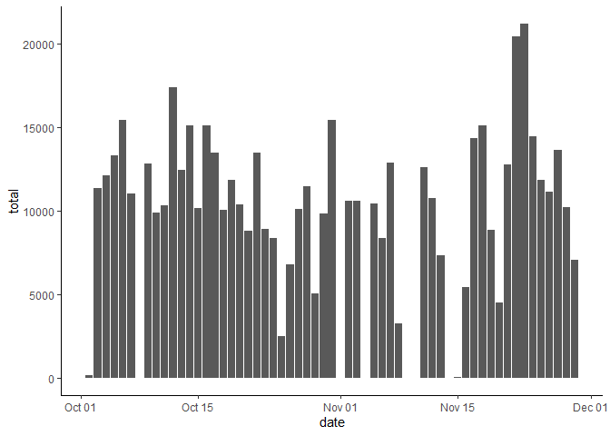

```r
prob2 <- activity %>%
group_by(date) %>%
summarize(total = sum(steps))

#png(filename="plot1.png")
prob2 %>%
ggplot() +
geom_col(aes(x=date, y=total ))+
  theme_classic()
```

```r
#dev.off()
```

### 3. Mean and median number of steps taken each day

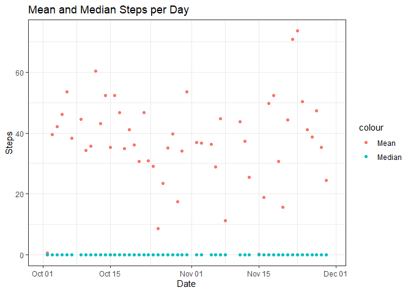

```r
#png(filename="plot2.png")
activity %>%
group_by(date) %>%
summarize(mean = mean(steps),
          median = median(steps))%>%
  ggplot() +
  geom_point(aes(date, mean, color = "Mean") )+
  geom_point(aes(date, median, color = "Median") ) +
  theme_bw() +
  labs(title = "Mean and Median Steps per Day",
       y = "Steps",
       x = "Date")
```

```r
#dev.off()
```

### 4. Time series plot of the average number of steps taken

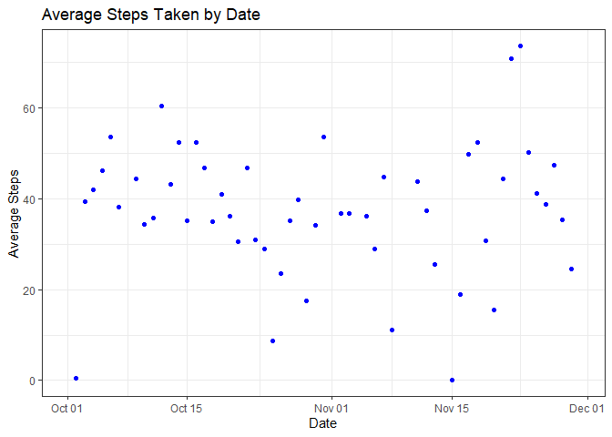

```r
#png(filename = "plot3.png")
activity %>%
group_by(date) %>%
summarize(avg = mean(steps)) %>%
ggplot() +
geom_point(aes(x=date, y=avg), color = "blue")+
  theme_bw() +
  labs(title = "Average Steps Taken by Date",
       y = "Average Steps",
       x= "Date")
```

```r
#dev.off()
```

```r
activity %>%
  group_by(interval) %>%
  summarize(mean = mean(steps, na.rm = TRUE)) %>%
  max()
```

```
## [1] 2355
```

### 6. Code to describe and show a strategy for imputing missing data

The data set contains 2 months of data broken down into 5 minute increments. Step 1: check dates to determine there is a pattern to the missing data Findings: 8 days missing 288 records each Step 2: group by day of the week and determine average number of steps per 5 minute increment. Step 3: Impute data for missing day of the week

```r
activity %>%
  filter(is.na(steps)) %>%
  group_by(date) %>%
  summarise(miss = n())
```

```
## # A tibble: 8 x 2
##   date        miss
##   <date>     <int>
## 1 2012-10-01   288
## 2 2012-10-08   288
## 3 2012-11-01   288
## 4 2012-11-04   288
## 5 2012-11-09   288
## 6 2012-11-10   288
## 7 2012-11-14   288
## 8 2012-11-30   288
```

```r
prob6 <- activity %>%
  mutate(day = wday(date, label = TRUE)) %>%
  group_by(day, interval) %>%
  summarize(avg = mean(steps, na.rm=TRUE))
prob6_2 <- activity %>%
  mutate(day = wday(date, label = TRUE))

temp <- prob6_2 %>%
  filter(date %in% c(ymd('2012-10-01', '2012-10-08', '2012-11-01', '2012-11-04', '2012-11-09', '2012-11-10', '2012-11-14', '2012-11-30'))) %>%
  right_join(prob6) %>%
  mutate(steps = avg) %>%
  select(!avg)
prob_6_3 <- prob6_2 %>%
  filter(!date %in% c(ymd('2012-10-01', '2012-10-08',
                          '2012-11-01', '2012-11-04',
                          '2012-11-09', '2012-11-10',
                          '2012-11-14', '2012-11-30'))) %>%
  bind_rows(temp)
```

### 7. Histogram of the total number of steps taken each day after missing values are imputed

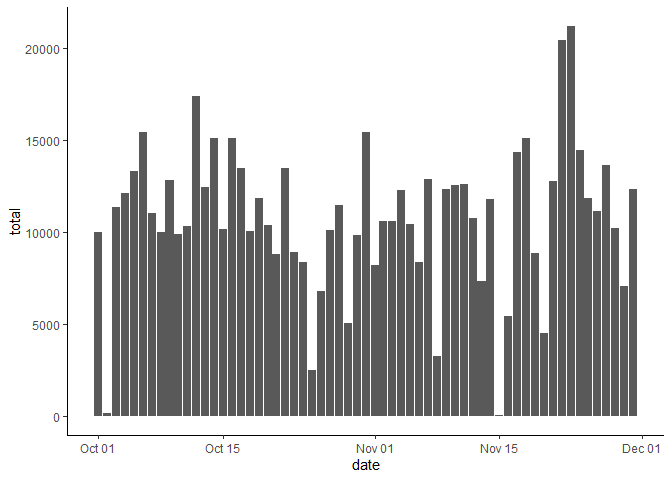

```r
#png(filename = "plot4.png")
prob_6_3 %>%
group_by(date) %>%
summarize(total = sum(steps)) %>%
ggplot() +
geom_col(aes(x=date, y=total ))+
  theme_classic()
```

```r
#dev.off()
```

### 8. Panel plot comparing the average number of steps taken per 5-minute interval across weekdays and weekends

```r
wkday <- c("Mon", "Tue", "Wed", "Thu", "Fri")
wkend <- c("Sat", "Sun")

prob_7_a <- prob_6_3 %>%
  filter(day %in% wkday) %>%
  mutate(wk = "Weekday")

prob_7_b <- prob_6_3 %>%
  filter(day %in% wkend) %>%
  mutate(wk = "Weekend")

prob_7 <- bind_rows(prob_7_a, prob_7_b) %>%
  group_by(interval, wk) %>%
  summarize(avg = mean(steps))
```

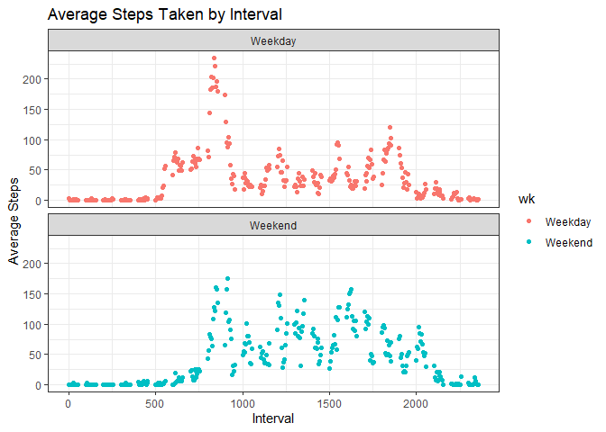

```r
#png(filename = "plot5.png")
  prob_7 %>%
  ggplot() +
  geom_point(aes(x=interval, y=avg, color = wk) )+
  theme_bw() +
  labs(title = "Average Steps Taken by Interval",
       y = "Average Steps",
       x= "Interval") +
  facet_wrap(~wk, dir="v")
```

```r
#  dev.off()
```